# Clustering NBA Teams

Yo

October 9, 2018

Question one may ask themselves - how could we come up with a stylistic grouping of NBA teams according to their performances in various statistical categories? How to determine clusters of “similar” teams?

E.g. one may claim from domain knowledge that San Antonio Spurs and Boston Celtics are pretty similar from many standpoints - solid system provided by tenured head coaches, great perimeter defense, average offense. How do we represent that from modeling/statistical standpoint?

First of all, one has to represent teams as **mathematical objects**. How though?

Just check a classical “Team Per Game Stats” table at https://www.basketball-reference.com/leagues/NBA_2018.html. Each team may be represented as a **vector** of numbers - **x** $= (FG, FGA, FG\%, .., PTS) = (x_1,x_2,x_3, ..., x_p) \in R^p$ etc. The number $p$ of statistical categories determines the length of that vector.

In NBA we got 30 teams, so we can get 30 vectors - **x**$_1$, **x**$_2$,…,**x**$_{30}$, each one representing the corresponding team $i, i=1,\dots,30$, as a mathematical object.

Now the questions of

- “how similar are teams A & B”, and
- “how can we group NBA teams stylistically”

are translated into

- “how close are are vectors $x_A$ and $x_B$”, and
- “how can we numerically group/cluster vectors corresponding to NBA teams”

Below we will proceed to

- Scrape the required data on NBA teams by the mid-season of 2017/18.
- Figure out the statistical categories worth retaining in order to describe an NBA teams.
- Apply a couple of clustering approaches to group NBA teams.

# Prepping the data.

## Scraping.

```r
library(rvest)  # Should be installed along with 'xml2'
# Link containing data of "Up until a particular date", we take "Up to January 18, 2018"
url_link <- 'https://www.basketball-reference.com/friv/standings.fcgi?month=1&day=18&year=2018&lg_id=NBA'

# Read the HTML webpage for that link into an R object
url <- read_html(url_link)
# Find a 'table' on that HTML page
table_one <- xml_find_all(url, "//table")
# Obtain the actual contents of the table, wrapped into a data frame
table_one <- html_table(table_one)
```

Upon that “basic initial scrape” we don’t get what we want right away - it only obtains first couple of tables from the page…

```r
length(table_one)
```

```
## [1] 2
```

```r
head(table_one[[1]])
```

```
##     Eastern Conference  W  L  W/L%  GB PW PL  PS/G  PA/G
## 1      Boston Celtics* 34 11 0.756   — 30 15 103.2  98.1
## 2     Toronto Raptors* 30 13 0.698   3 31 12 112.0 104.3
## 3 Cleveland Cavaliers* 26 17 0.605   7 23 20 109.5 108.7
## 4          Miami Heat* 26 18 0.591 7.5 21 23 101.2 101.8
## 5  Washington Wizards* 25 20 0.556   9 25 20 106.9 105.3
## 6      Indiana Pacers* 24 20 0.545 9.5 24 20 107.4 106.0
```

```r
head(table_one[[2]])
```

```
##        Western Conference  W  L  W/L%   GB PW PL  PS/G  PA/G
## 1  Golden State Warriors* 37  9 0.804    — 35 11 115.9 106.9
## 2        Houston Rockets* 30 12 0.714    5 30 12 114.6 107.1
## 3      San Antonio Spurs* 30 16 0.652    7 28 18 101.3  97.9
## 4 Minnesota Timberwolves* 29 17 0.630    8 29 17 108.7 104.8
## 5  Oklahoma City Thunder* 25 20 0.556 11.5 28 17 104.3 100.8
## 6 Portland Trail Blazers* 23 21 0.523   13 23 21 104.0 103.3
```

We need to refer to our $find\_extra\_table()$ function (details in previous meetup files) to dig out the rest of the tables from that page:

```r
find_extra_table <- function(url_link){
  # Additional tables are within the comment tags -  between "<!--"  and  "-->"
  # Which is why your xpath is missing them.

  # Find all the commented nodes.
  # xml_find_all looks in-between the <> of the object resulting from read_html().
  alt_tables <- xml_find_all(read_html(url_link),"//comment()")

  #Among commented nodes, find those containing '<table' reg. expression
  #raw_parts <- as.character(alt_tables[grep("\\</?table", as.character(alt_tables))])
  raw_parts <- as.character(alt_tables[grep("<table", as.character(alt_tables))])

  # Remove the comment begin ("<!--") and end ("-->") tags
  strip_html <- stringi::stri_replace_all_regex(raw_parts, c("<\\!--","-->"),c("",""),
                                                vectorize_all = FALSE)

  # Read all the tables that used to be commented before.
  alt_tables <- lapply(grep("<table", strip_html, value = TRUE), function(i){
    rvest::html_table(xml_find_all(read_html(i), "//table"))[[1]]
  })

  return(alt_tables)
}
```

Below we apply $find\_extra\_table()$ function to our $url\_link$, and save the team’s and opponent’s stats into appropriately named objects:

```r
url_link <- 'https://www.basketball-reference.com/friv/standings.fcgi?month=1&day=18&year=2018&lg_id=NBA'

all_stats <- find_extra_table(url_link)
team_stats <- all_stats[[1]]
opp_stats <- all_stats[[2]]

# To be more memory efficient
rm(all_stats)
team_stats$Rk <- opp_stats$Rk <- NULL
# Get rid of league averages.
team_stats <- team_stats[-nrow(team_stats),]
opp_stats <- opp_stats[-nrow(opp_stats),]

#
head(team_stats)
```

```
##                     Team  G    MP   FG  FGA   FG%  3P  3PA   3P%   2P  2PA
## 1  Golden State Warriors 46 11090 2004 3935 0.509 530 1364 0.389 1474 2571
## 2        Houston Rockets 42 10130 1652 3594 0.460 661 1830 0.361  991 1764
## 3        Toronto Raptors 43 10370 1767 3764 0.469 481 1373 0.350 1286 2391
## 4   New Orleans Pelicans 44 10685 1823 3737 0.488 475 1285 0.370 1348 2452
## 5    Cleveland Cavaliers 43 10345 1696 3600 0.471 520 1407 0.370 1176 2193
## 6 Minnesota Timberwolves 46 11115 1872 3928 0.477 367 1039 0.353 1505 2889
##     2P%  FT  FTA   FT% ORB  DRB  TRB  AST STL BLK TOV  PF  PTS
## 1 0.573 795  974 0.816 389 1661 2050 1401 375 365 701 914 5333
## 2 0.562 850 1068 0.796 407 1445 1852  943 371 197 601 863 4815
## 3 0.538 799  994 0.804 422 1442 1864  980 359 257 559 957 4814
## 4 0.550 752  988 0.761 369 1519 1888 1156 330 224 675 854 4873
## 5 0.536 797  992 0.803 367 1431 1798 1003 313 164 589 798 4709
## 6 0.521 887 1116 0.795 483 1437 1920 1046 419 193 559 825 4998
```

```r
head(opp_stats)
```

```
##                    Team  G    MP   FG  FGA   FG%  3P  3PA   3P%   2P  2PA
## 1     San Antonio Spurs 46 11040 1728 3854 0.448 426 1222 0.349 1302 2632
## 2        Boston Celtics 45 10850 1635 3796 0.431 405 1205 0.336 1230 2591
## 3 Oklahoma City Thunder 45 10900 1664 3686 0.451 481 1358 0.354 1183 2328
## 4       Detroit Pistons 43 10320 1650 3554 0.464 451 1207 0.374 1199 2347
## 5            Miami Heat 44 10610 1641 3618 0.454 408 1113 0.367 1233 2505
## 6             Utah Jazz 44 10585 1653 3548 0.466 452 1180 0.383 1201 2368
##     2P%  FT FTA   FT% ORB  DRB  TRB  AST STL BLK TOV  PF  PTS
## 1 0.495 620 842 0.736 418 1523 1941  973 363 164 624 899 4502
## 2 0.475 741 968 0.765 438 1548 1986  900 314 188 616 853 4416
## 3 0.508 727 964 0.754 419 1436 1855  985 362 198 688 913 4536
## 4 0.511 623 804 0.775 391 1456 1847 1045 308 228 646 767 4374
## 5 0.492 790 999 0.791 378 1468 1846  882 328 200 581 851 4480
## 6 0.507 727 939 0.774 380 1518 1898  890 353 187 665 856 4485
```

## Wrangling, Transforming Data into Needed Format.

Next, we need to obtain **per-game averages** in such categories as FG made, attempted (FGM/A), 3PTM/A, FTM/A, offensive rebounds (ORB), DRB, TRB, AST, STL, BLK, TOV, PF, PTS.

All but the %-type of stats (FG%, 3PT% etc). We can obtain indices of those %-stats and other unwanted columns (team names) as follows (again some **data wrangling**/**string operations**):

```r
ind.exclude <- which(grepl("%",names(team_stats)))
ind.exclude <- c(ind.exclude, which(grepl("[a-z]",names(team_stats))))
ind.exclude
```

```
## [1]  6  9 12 15  1
```

Then we only modify these stats, via dividing them by the games played ($G$ column):

```r
team_stats[,-ind.exclude] <- apply(team_stats[,-ind.exclude],
                                      2,
                                      function(x) x/team_stats$G)

opp_stats[,-ind.exclude] <- apply(opp_stats[,-ind.exclude],
                                      2,
                                      function(x) x/opp_stats$G)
```

Resulting table is much closer to what we were looking at in the beginning (which was per game stats for the whole 2017/18 season, but we actually just obtained them up until mid-season).

```r
head(team_stats)
```

```
##                     Team G       MP       FG      FGA   FG%        3P
## 1  Golden State Warriors 1 241.0870 43.56522 85.54348 0.509 11.521739
## 2        Houston Rockets 1 241.1905 39.33333 85.57143 0.460 15.738095
## 3        Toronto Raptors 1 241.1628 41.09302 87.53488 0.469 11.186047
## 4   New Orleans Pelicans 1 242.8409 41.43182 84.93182 0.488 10.795455
## 5    Cleveland Cavaliers 1 240.5814 39.44186 83.72093 0.471 12.093023
## 6 Minnesota Timberwolves 1 241.6304 40.69565 85.39130 0.477  7.978261
##        3PA   3P%       2P      2PA   2P%       FT      FTA   FT%       ORB
## 1 29.65217 0.389 32.04348 55.89130 0.573 17.28261 21.17391 0.816  8.456522
## 2 43.57143 0.361 23.59524 42.00000 0.562 20.23810 25.42857 0.796  9.690476
## 3 31.93023 0.350 29.90698 55.60465 0.538 18.58140 23.11628 0.804  9.813953
## 4 29.20455 0.370 30.63636 55.72727 0.550 17.09091 22.45455 0.761  8.386364
## 5 32.72093 0.370 27.34884 51.00000 0.536 18.53488 23.06977 0.803  8.534884
## 6 22.58696 0.353 32.71739 62.80435 0.521 19.28261 24.26087 0.795 10.500000
##        DRB      TRB      AST      STL      BLK      TOV       PF      PTS
## 1 36.10870 44.56522 30.45652 8.152174 7.934783 15.23913 19.86957 115.9348
## 2 34.40476 44.09524 22.45238 8.833333 4.690476 14.30952 20.54762 114.6429
## 3 33.53488 43.34884 22.79070 8.348837 5.976744 13.00000 22.25581 111.9535
## 4 34.52273 42.90909 26.27273 7.500000 5.090909 15.34091 19.40909 110.7500
## 5 33.27907 41.81395 23.32558 7.279070 3.813953 13.69767 18.55814 109.5116
## 6 31.23913 41.73913 22.73913 9.108696 4.195652 12.15217 17.93478 108.6522
```

```r
head(opp_stats)
```

```
##                    Team G       MP       FG      FGA   FG%        3P
## 1     San Antonio Spurs 1 240.0000 37.56522 83.78261 0.448  9.260870
## 2        Boston Celtics 1 241.1111 36.33333 84.35556 0.431  9.000000
## 3 Oklahoma City Thunder 1 242.2222 36.97778 81.91111 0.451 10.688889
## 4       Detroit Pistons 1 240.0000 38.37209 82.65116 0.464 10.488372
## 5            Miami Heat 1 241.1364 37.29545 82.22727 0.454  9.272727
## 6             Utah Jazz 1 240.5682 37.56818 80.63636 0.466 10.272727
##        3PA   3P%       2P      2PA   2P%       FT      FTA   FT%      ORB
## 1 26.56522 0.349 28.30435 57.21739 0.495 13.47826 18.30435 0.736 9.086957
## 2 26.77778 0.336 27.33333 57.57778 0.475 16.46667 21.51111 0.765 9.733333
## 3 30.17778 0.354 26.28889 51.73333 0.508 16.15556 21.42222 0.754 9.311111
## 4 28.06977 0.374 27.88372 54.58140 0.511 14.48837 18.69767 0.775 9.093023
## 5 25.29545 0.367 28.02273 56.93182 0.492 17.95455 22.70455 0.791 8.590909
## 6 26.81818 0.383 27.29545 53.81818 0.507 16.52273 21.34091 0.774 8.636364
##        DRB      TRB      AST      STL      BLK      TOV       PF       PTS
## 1 33.10870 42.19565 21.15217 7.891304 3.565217 13.56522 19.54348  97.86957
## 2 34.40000 44.13333 20.00000 6.977778 4.177778 13.68889 18.95556  98.13333
## 3 31.91111 41.22222 21.88889 8.044444 4.400000 15.28889 20.28889 100.80000
## 4 33.86047 42.95349 24.30233 7.162791 5.302326 15.02326 17.83721 101.72093
## 5 33.36364 41.95455 20.04545 7.454545 4.545455 13.20455 19.34091 101.81818
## 6 34.50000 43.13636 20.22727 8.022727 4.250000 15.11364 19.45455 101.93182
```

It’s been fun having the $Games \ (G)$ and $Minutes \ Played \ (MP)$ columns for semi-sanity checking, but all fun has to come to an end, as we don’t need those at all from now on.

```r
team_stats$G <- opp_stats$G <- NULL
team_stats$MP <- opp_stats$MP <- NULL
```

## Feature/variable “selection”.

Now that we got a long list of stats for each team, we’d like to narrow that list down for the following reasons:

- We only have $n=30$ teams, and in order to have meaningful clustering, we would want number of variables $p$ to be considerably $<n$. Otherwise we get into many computational/theoretical issues.
- We wouldn’t want to have heavily correlated features.
- We need to watch out for **collinearity** (e.g. FG = 3P + 2P, FGA = 3PA + 2PA, etc)

First, let’s check the fancy correlation matrix (see details in previous meetup materials) for the team’s own stats:

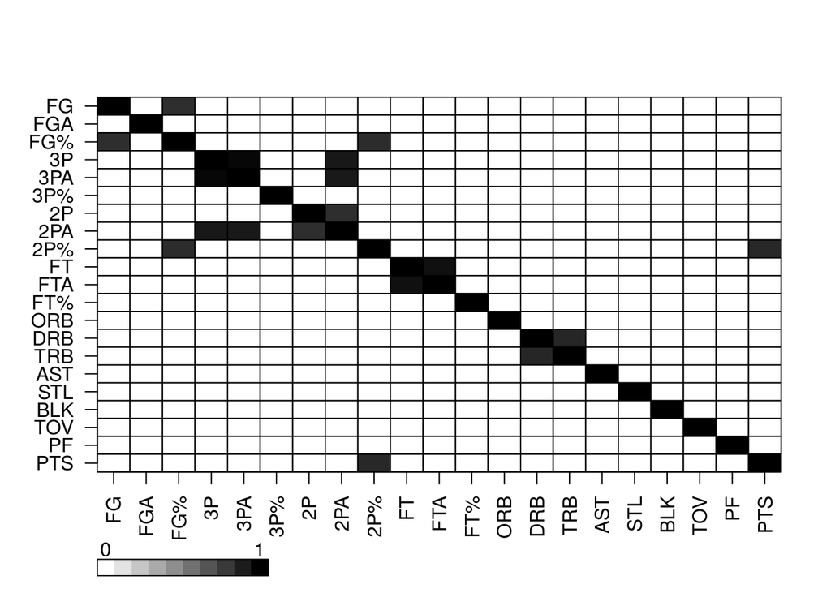

```r
library(plotrix)

abs.cor <- abs(cor(team_stats[,-1]))
abs.thresh.cor <- ifelse(abs.cor >= 0.8, abs.cor, 0)

color2D.matplot(abs.thresh.cor,
                cs1=c(1,0),cs2=c(1,0),cs3=c(1,0),
                show.legend=T,
                xlab='',
                ylab='',
                axes=F)

par(las=2)
axis(1,at=c(1:ncol(abs.thresh.cor))-0.5,labels=colnames(abs.thresh.cor))
par(las=1)
axis(2,at=c(ncol(abs.thresh.cor):1)-0.5,labels=colnames(abs.thresh.cor))
```

Let’s dispose of certain correlated variables (leaving only one from a correlated group) taking into account our **final goal** - select features that **describe the team stylistically**, so that they could be interpreted as a **team quality** concept:

- $FG$ and $FG\%$ are correlated - I’d leave in just $FG\%$, because we can easily associate it with the concept of “team shooting efficiency”; Plus $FGA$ - corresponding to the concept of “pace” (maybe?) - will pick up the slack on explaining how many shots did the team actually take to produce this efficiency.
- $3PA$ correlates with $3P$ - I’d leave in $3PA$, shows tendency/willingness to shoot threes, while $3P\%$ will take care of efficiency
- I’d fully dispose of $2P$ shooting, as it’d be collinear for total FG and 3P, while also heavily negatively correlated with $3P$.
- I’d dispose of $FT$/$FTA$. Can’t waste space on that… But again - I might be wrong.
- From the $ORB$/$DRB$/$TRB$ triple, which is collinear ($TRB = ORB + DRB$), I’d leave in $TRB$ (overall rebounding prowess) and $ORB$ (activity on offensive boards).
- $AST, BLK, Fouls(PF), TOV$ are all good as stand-alone stats and good for describing a team (ball-sharing offense, rim-protecting defense, physical defense, careless offense, respectively)
- I’d get rid of $STL$ because I will use $TOV$ from the $opponent$ table to take care of “all things forced turnovers”.
- Should I get rid of points? It feels weird to me to use points as a way to describe team’s “style”, especially when I already have pace, efficiency and all that..

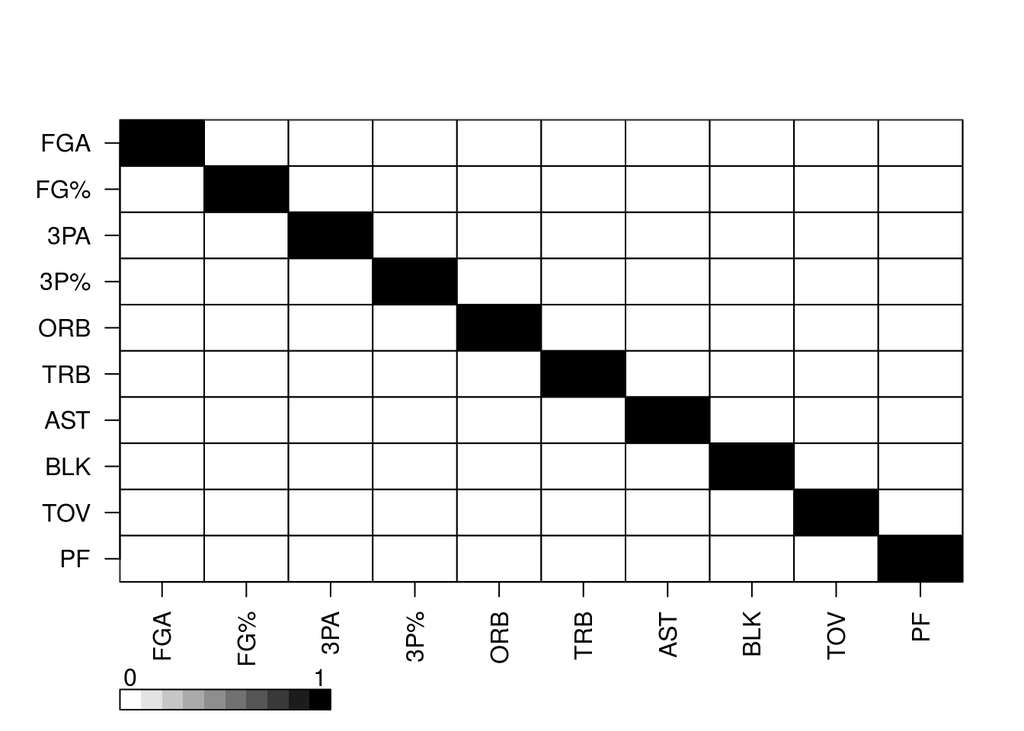

```r
### Var "selection": gotta really minimize the selection, as we just got 30 teams.
needed.vars.team <- c("FGA","FG%","3PA","3P%", "ORB", "TRB", "AST", "BLK", "TOV","PF")

color2D.matplot(abs.thresh.cor[needed.vars.team,needed.vars.team],
                cs1=c(1,0),cs2=c(1,0),cs3=c(1,0),
                show.legend=T,
                xlab='',
                ylab='',
                axes=F)

par(las=2)
axis(1,at=c(1:length(needed.vars.team))-0.5,labels=needed.vars.team)
par(las=1)
axis(2,at=c(length(needed.vars.team):1)-0.5,labels=needed.vars.team)
```

As far as the “Opponent Per Game” stats are concerned:

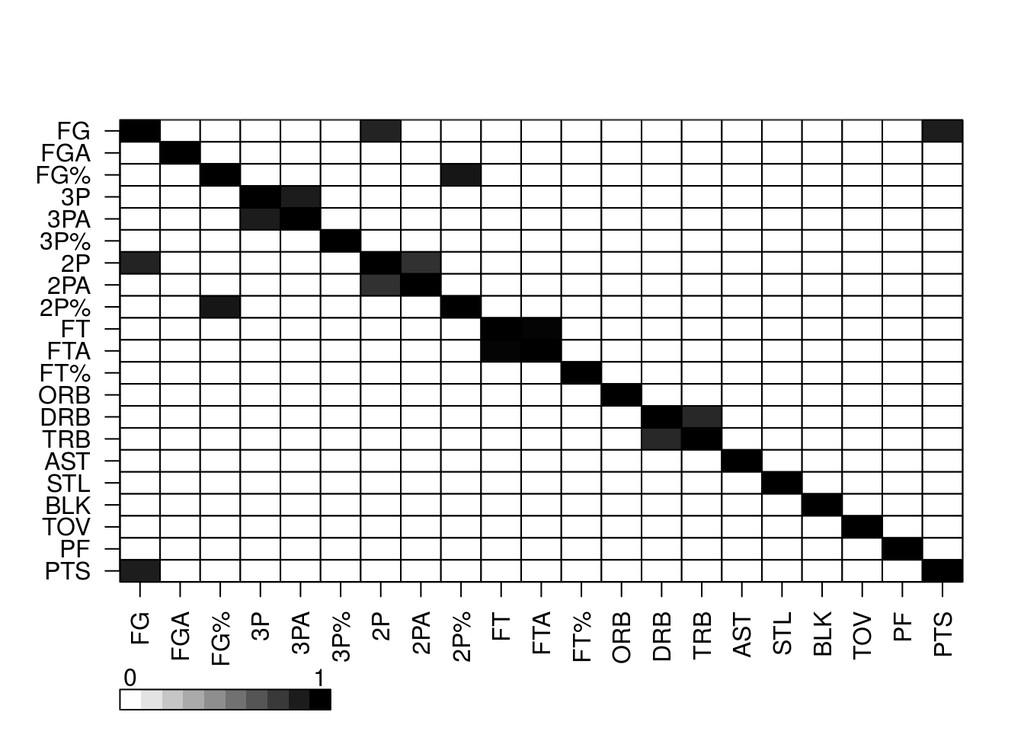

```r
abs.cor <- abs(cor(opp_stats[,-1]))

abs.thresh.cor <- ifelse(abs.cor >= 0.8, abs.cor, 0)

color2D.matplot(abs.thresh.cor,
                cs1=c(1,0),cs2=c(1,0),cs3=c(1,0),
                show.legend=T,
                xlab='',
                ylab='',
                axes=F)

par(las=2)
axis(1,at=c(1:ncol(abs.thresh.cor))-0.5,labels=colnames(abs.thresh.cor))
par(las=1)
axis(2,at=c(ncol(abs.thresh.cor):1)-0.5,labels=colnames(abs.thresh.cor))
```

Won’t specify my thought process here, and you can always make your modifications in terms of which variables we should select:

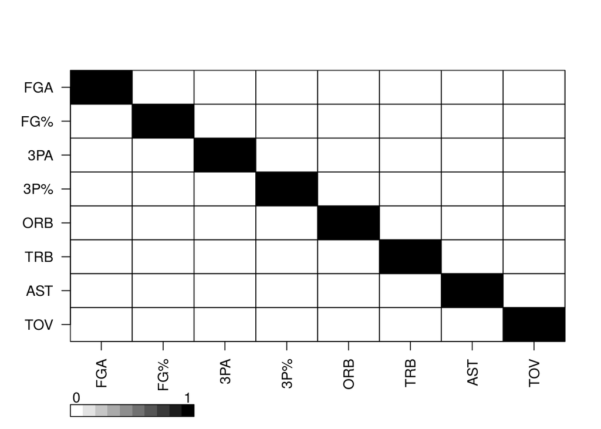

```r
# Var "selection": minimize the selection.

needed.vars.opp <- c("FGA","FG%","3PA", "3P%",  "ORB", "TRB", "AST", "TOV")

color2D.matplot(abs.thresh.cor[needed.vars.opp,needed.vars.opp],
                cs1=c(1,0),cs2=c(1,0),cs3=c(1,0),
                show.legend=T,
                xlab='',
                ylab='',
                axes=F)

par(las=2)
axis(1,at=c(1:length(needed.vars.opp))-0.5,labels=needed.vars.opp)
par(las=1)
axis(2,at=c(length(needed.vars.opp):1)-0.5,labels=needed.vars.opp)
```

## Merging offensive and defensive data frames.

Now, let’s dispose of all the unneeded variables, and **merge our two data frames** into a single one that contains all the relevant info on each team. Now **each row** of the resulting merged frame can act as a **vector representing the team** for further **clustering**.

```r
## MERGING:

all_stats <- merge(team_stats[,c("Team",needed.vars.team)],
                   opp_stats[,c("Team",needed.vars.opp)],
                   by = "Team")
head(all_stats)
```

```
##                  Team    FGA.x FG%.x    3PA.x 3P%.x     ORB.x    TRB.x
## 1       Atlanta Hawks 85.11364 0.452 29.04545 0.372  9.795455 40.90909
## 2      Boston Celtics 84.40000 0.449 31.53333 0.369  9.177778 44.71111
## 3       Brooklyn Nets 87.08889 0.435 34.15556 0.348 10.200000 45.66667
## 4   Charlotte Hornets 86.55814 0.442 25.60465 0.359 10.441860 46.62791
## 5       Chicago Bulls 88.66667 0.441 30.46667 0.361  9.244444 44.62222
## 6 Cleveland Cavaliers 83.72093 0.471 32.72093 0.370  8.534884 41.81395
##      AST.x      BLK    TOV.x       PF    FGA.y FG%.y    3PA.y 3P%.y
## 1 23.77273 4.068182 14.95455 20.02273 85.27273 0.472 30.77273 0.371
## 2 22.15556 4.644444 13.28889 20.08889 84.35556 0.431 26.77778 0.336
## 3 22.37778 3.977778 14.84444 20.82222 89.04444 0.461 25.51111 0.359
## 4 20.69767 4.558140 12.74419 17.95349 87.09302 0.456 30.18605 0.358
## 5 23.68889 3.711111 13.02222 18.88889 87.17778 0.468 30.80000 0.370
## 6 23.32558 3.813953 13.69767 18.55814 87.58140 0.472 32.25581 0.372
##       ORB.y    TRB.y    AST.y    TOV.y
## 1 10.795455 43.65909 25.61364 15.61364
## 2  9.733333 44.13333 20.00000 13.68889
## 3  9.777778 46.00000 21.40000 12.62222
## 4  8.325581 43.62791 23.39535 13.46512
## 5  8.266667 45.57778 25.00000 12.51111
## 6 10.441860 44.00000 25.74419 13.32558
```

```r
# For further convenience, make the Team column to be ROW NAMES,
# while disposing of the column itself. This way we will remain
# with only numeric columns => perfect for clustering.

rownames(all_stats) <- all_stats[,1]
all_stats$Team <- NULL
```

# Clustering.

Now that we’ve settled on the feature vectors that describe each team, we can proceed to clustering.

## Scaling.

Prior to applying any clustering methods, first and foremost one should **scale the data**. Clustering is a very geometrical method, which heavily depends on distances between vectors.

It is very sensitive to the variable scales, and can be easily dominated by variables that have higher standard deviations (due to units of measurement, for example).

Just as a toy example, presume you have a Team A that takes 83 FGA and shoots 0.40 from the field, while

- Team B has 83 FGA and shoots 0.30 from the field.
- Team C has 84 FGA and shoots 0.40 from the field.

Which team (B or C) is more similar to A?

From logical perspective, difference of 1 FG attempt is nothing compared to 0.1 in field goal percentage, and we’d consider team C to be closer to A.

But from clustering algorithm’s perspective, 1 is always greater than 0.1, and it will claim that Team B is closer stylistically to Team A, which is something that can be avoided by **scaling**.

**Scaling a variable** *X* means **dividing it by its STANDARD DEVIATION**. For example, scaling $FGA$ variable means substituting it for $FGA/sd(FGA)$. Scaling the whole data set? You simply scale **each variable (<-> column)** of the data set (e.g. $FGA$ for $FGA/sd(FGA)$, $FG\%$ for $FG\%/sd(FG\%)$, etc).

That way we obtain the **same measure units** for **each variable**. Now they are all measured in **standard deviations** (1 unit = 1 standard deviation). What did we have before scaling? We had $FG\%$ measured in percentages, $FGA$ in attempts (**different units**).

For a toy example, let’s look at $(FGA, FG\%)$ pair of variables, and check out three teams: $Wizards$, $Warriors$, $76ers$. In particular, we’ll see how close are $Wizards$ to the other two teams.

**Before scaling**: $Wizards$ are considered to be closer to GSW in shooting from the field than they are to Philly.

```r
all_stats[c(30,10,23),c("FGA.x","FG%.x")]       # FGA, FG% values for 3 teams
```

```
##                          FGA.x FG%.x
## Washington Wizards    85.73333 0.465
## Golden State Warriors 85.54348 0.509
## Philadelphia 76ers    86.80000 0.462
```

```r
dist(all_stats[c(30,10,23),c("FGA.x","FG%.x")]) # Eucledian distances between 3 teams
```

```
##                       Washington Wizards Golden State Warriors
## Golden State Warriors           0.194887
## Philadelphia 76ers              1.066671              1.257400
```

**After scaling**: We’re back to normal. $Wizards$ are closer to $Philly$ than to $GSW$.

```r
all_stats.scaled <- scale(all_stats) # Scaling (dividing each) # Scaling (dividing each variable by its st. dev.)

all_stats.scaled[c(30,10,23),c("FGA.x","FG%.x")]
```

```
##                           FGA.x     FG%.x
## Washington Wizards    0.1778992 0.3440038
## Golden State Warriors 0.0794953 3.1128149
## Philadelphia 76ers    0.7307636 0.1552212
```

```r
dist(all_stats.scaled[c(30,10,23),c("FGA.x","FG%.x")])  # Distances for SCALED data.
```

```
##                       Washington Wizards Golden State Warriors
## Golden State Warriors          2.7705591
## Philadelphia 76ers             0.5842072             3.0284502
```

Now let’s scale the whole data set for good:

```r
all_stats <- scale(all_stats)
head(all_stats)
```

```
##                          FGA.x      FG%.x       3PA.x      3P%.x
## Atlanta Hawks       -0.1432963 -0.4740540  0.08545104  0.7051611
## Boston Celtics      -0.5131814 -0.6628366  0.67064592  0.4801097
## Brooklyn Nets        0.8804978 -1.5438219  1.28744085 -1.0952502
## Charlotte Hornets    0.6054048 -1.1033293 -0.72388924 -0.2700617
## Chicago Bulls        1.6982765 -1.1662568  0.41974629 -0.1200274
## Cleveland Cavaliers -0.8651504  0.7215689  0.94999057  0.5551268
##                          ORB.x      TRB.x      AST.x        BLK      TOV.x
## Atlanta Hawks        0.1001512 -1.0641616  0.5101253 -0.8433087  0.7803955
## Boston Celtics      -0.4281955  0.6744998 -0.2655101 -0.1593448 -0.6375360
## Brooklyn Nets        0.4461903  1.1114747 -0.1589268 -0.9506089  0.6866693
## Charlotte Hornets    0.6530722  1.5510493 -0.9647458 -0.2617798 -1.1012278
## Chicago Bulls       -0.3711703  0.6338510  0.4699144 -1.2671145 -0.8645426
## Cleveland Cavaliers -0.9781125 -0.6503685  0.2956631 -1.1450513 -0.2895472
##                              PF       FGA.y      FG%.y      3PA.y
## Atlanta Hawks       -0.07659421 -0.04002798  1.0060412  1.0626125
## Boston Celtics      -0.03615665 -0.34737244 -2.3114673 -0.9358576
## Brooklyn Nets        0.41205196  1.22387534  0.1159779 -1.5695065
## Charlotte Hornets   -1.34129970  0.56995364 -0.2885963  0.7691260
## Chicago Bulls       -0.76958893  0.59835490  0.6823818  1.0762557
## Cleveland Cavaliers -0.97174080  0.73360724  1.0060412  1.8045254
##                          3P%.y       ORB.y     TRB.y      AST.y      TOV.y
## Atlanta Hawks        0.6535724  1.28630224 0.2836204  1.7627781  1.8720075
## Boston Celtics      -2.0063152  0.06617793 0.5959440 -1.6465547 -0.4044872
## Brooklyn Nets       -0.2583891  0.11723401 1.8252819 -0.7962919 -1.6660869
## Charlotte Hornets   -0.3343859 -1.55099378 0.2630835  0.4155444 -0.6691542
## Chicago Bulls        0.5775756 -1.61867277 1.5472174  1.3900980 -1.7975036
## Cleveland Cavaliers  0.7295692  0.88010686 0.5081342  1.8420649 -0.8341890
```